# Project - Read Alignment and QC

Alexander Ham

2023-04-03

## STAR Alignment

I aligned each pair of paired-end reads to the indexed GRCmm39 reference genome, and directed the output to separate directories.

```
#!/bin/bash -l

#SBATCH --partition=angsd_class
#SBATCH --nodes=1
#SBATCH --ntasks=1
#SBATCH --cpus-per-task=8
#SBATCH --job-name=align_reads
#SBATCH --time=02:00:00
#SBATCH --mem=36G

mamba activate angsd

pair1="None"
pair2="None"
for file in *.fastq.gz; do
        if [[ ${pair1} == "None" ]]; then
                pair1=${file}
        else
                pair2=${file}
                dir_name=$(cut -d "_" -f 1-3 <<< ${pair1})
                mkdir ${dir_name}

                STAR --runMode alignReads \
                --runThreadN 8 \
                --genomeDir GRCm39_STARindex \
                --readFilesIn ${pair1} ${pair2} \
                --readFilesCommand zcat \
                --outFileNamePrefix ./${dir_name}/${dir_name} \
                --outSAMtype BAM SortedByCoordinate \

                pair1="None"
                pair2="None"
        fi;
done
exit
```

## Alignment MultiQC

I checked each alignment using MultiQC.

```
#!/bin/bash -l

#SBATCH --partition=angsd_class
#SBATCH --nodes=1
#SBATCH --ntasks=1
#SBATCH --cpus-per-task=1
#SBATCH --job-name=run_multiqc
#SBATCH --time=02:00:00
#SBATCH --mem=8G

mamba activate multiqc

for dir in ERR*/; do
        filename=$(cut -d "_" -f 3 <<< ${dir})
        multiqc --outdir ./multiqc_reports --filename "${filename}_multiqc" ./${dir};
done

exit
```

LFD1 is an outlier in terms of unmapped reads. While other replicates still have a large number of unmapped reads, 45 - 65% of their reads are uniquely mapped. LFD1 only has 25% uniquely mapped reads. It may be a good idea to exclude this replicate to avoid bias from the small proportion of uniquely mapped reads.

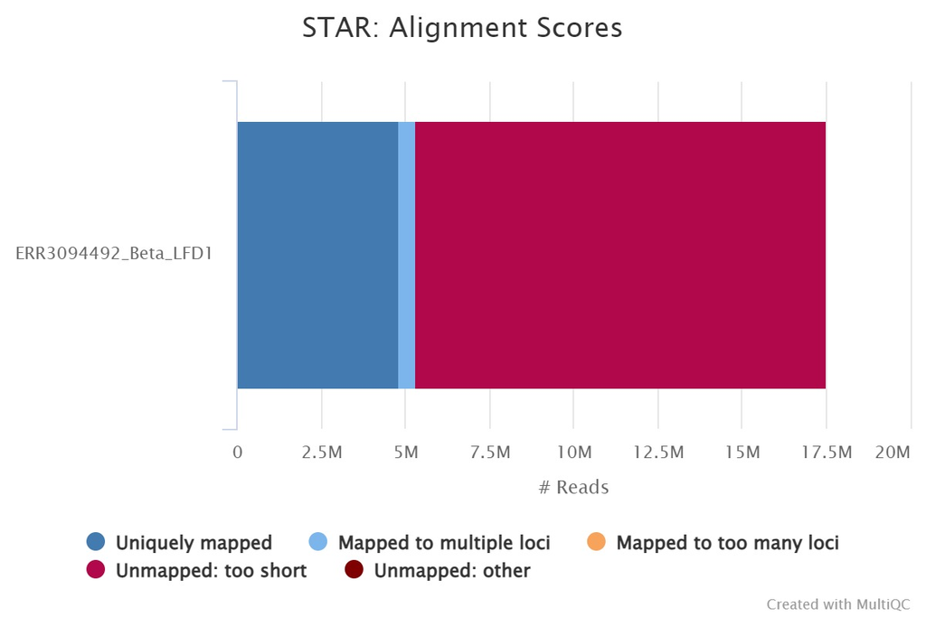

## FastQC

I also ran FastQC on each fastq file. Checking the over-represented sequences for each sample, it seems that each sample has varying degrees of bacterial contamination. Doing a BLAST search on the top over-represented sequence in each sample either results in bacterial DNA or Mouse Ins2 gene. This is true for both LFD and HFD samples. Apart from over-represented sequences, the fastq files passed FastQC tests.

```
#!/bin/bash -l

#SBATCH --partition=angsd_class
#SBATCH --nodes=1
#SBATCH --ntasks=1
#SBATCH --job-name=run_fastqc
#SBATCH --time=02:00:00
#SBATCH --mem=8G

mamba activate angsd

for file in *.fastq.gz; do
        fastqc ${file} -o fastqc_reports/;
done

exit
```

## RSeQC Read Distribution

I analyzed Read Distribution using RSeQC

```
#!/bin/bash -l

#SBATCH --partition=angsd_class
#SBATCH --nodes=1
#SBATCH --ntasks=1
#SBATCH --cpus-per-task=1
#SBATCH --job-name=run_rseqc
#SBATCH --time=02:00:00
#SBATCH --mem=8G

mamba activate rseqc

for dir in ERR*/; do
        filename=$(find ${dir} -maxdepth 1 -name "*.bam" -print -quit | xargs basename);
        path=${dir}${filename};
        read_distribution.py -i ${path} -r GRCm39.bed;
done

exit
```

I saved the output tables from each .bam file as separate .txt files. I loaded each of them into R and accumulated all of their values into one table

```r
setwd('C:/Users/hamal/OneDrive/Documents/ANGSD/Project/Project_Files/rseqc_reports/read_dist')
read.dist <- read.table("1.txt", header = TRUE)
for (i in seq(2,8)){
  #load next table
  read.dist.temp <- read.table(paste0(i, ".txt"), header = TRUE)
  #add tag_count
  read.dist[, 3] <- read.dist[, 3] + read.dist.temp[, 3]
  #get average of tags/kb
  read.dist[, 4] <- (read.dist[, 4] + read.dist.temp[, 4]) / 2
}
read.dist
```

```
##            Group Total_bases Tag_count     Tags.Kb
## 1      CDS_Exons    37568454 104713965 361.8248438
## 2    5'UTR_Exons    41438250  17158860  56.5967188
## 3    3'UTR_Exons    53952753  35966411  89.9978906
## 4        Introns  1105253088   9230883   1.0425781
## 5     TSS_up_1kb    25691519    140237   0.6964844
## 6     TSS_up_5kb   116205471    361125   0.4110938
## 7    TSS_up_10kb   209873182    482045   0.3014062
## 8   TES_down_1kb    28222917   1174235   6.4953906
## 9   TES_down_5kb   121418918   1614850   1.9678906
## 10 TES_down_10kb   214350577   1905837   1.3001562
```

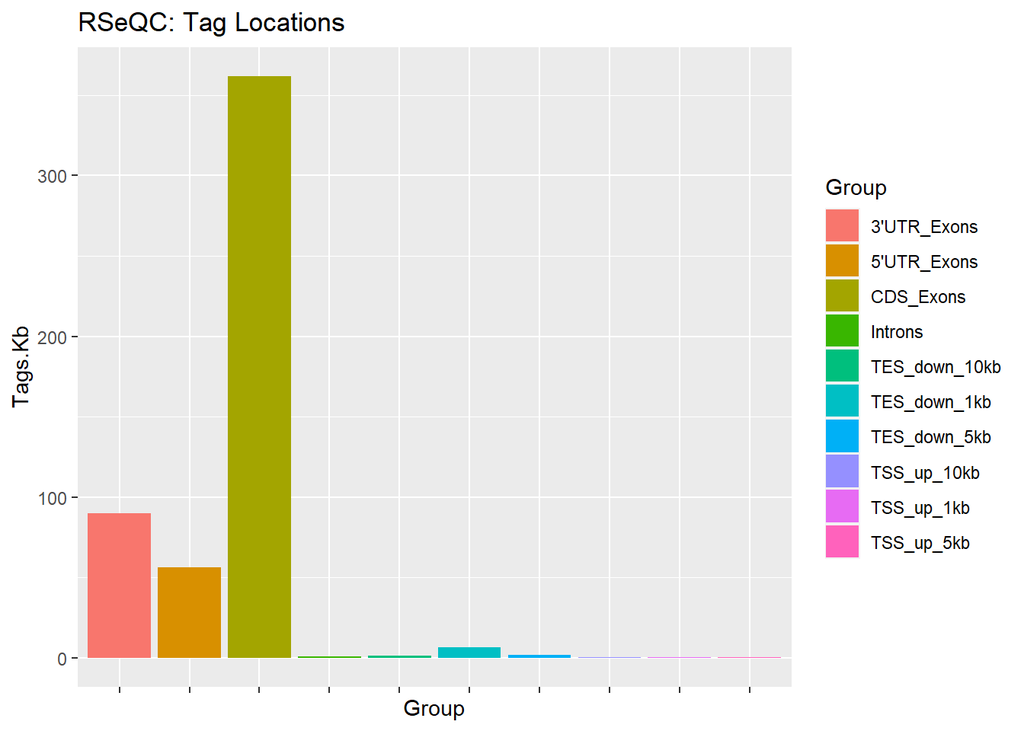

```r
dist.plot <- ggplot(data = read.dist, aes(x=Group, y=Tags.Kb,fill=Group))+
  geom_col() + theme(axis.text.x=element_blank()) + ggtitle("RSeQC: Tag Locations")

dist.plot
```

Next I analyzed gene body distributions. I created a subset of my genome-wide .bed file to represent only chromosomes 1-4 so the function would take less time.

```
#!/bin/bash -l

#SBATCH --partition=angsd_class
#SBATCH --nodes=1
#SBATCH --ntasks=1
#SBATCH --cpus-per-task=1
#SBATCH --job-name=run_rseqc
#SBATCH --time=08:00:00
#SBATCH --mem=8G

mamba activate rseqc

geneBody_coverage.py -i bampaths.txt -r GRCm39_chr1-4.bed -o rseqc_qc/group;

exit
```

The gene body distribution curves show that as a whole, the LFD samples have a greater 3’ bias than HFD samples. HFD2 and HFD3 clearly have the least 3’ bias and LFD1 and LFD2 have the greatest 3’ bias. It is possible that the LFD samples have more degraded mRNA, which could potentially be a source of bias.

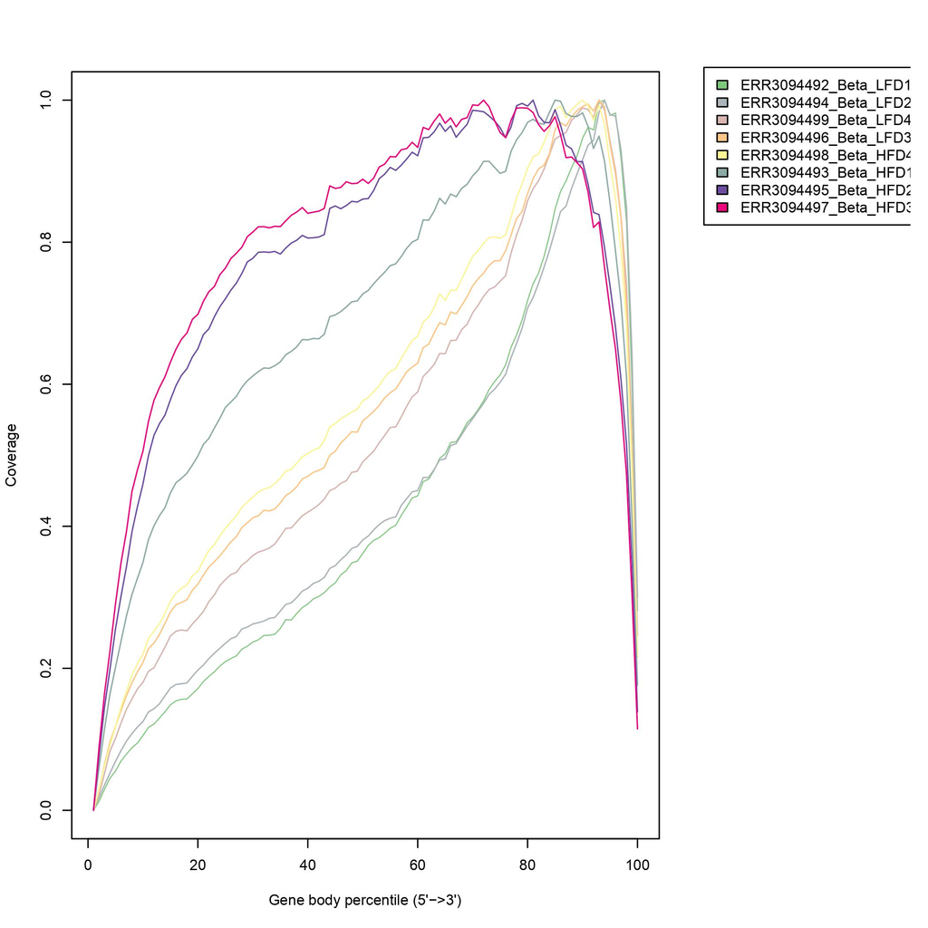

## featureCounts QC

I ran featureCounts on all alignments excluding LFD1, since it presented significantly more contamination than other samples in the MultiQC report.

```
#!/bin/bash -l

#SBATCH --partition=angsd_class
#SBATCH --nodes=1
#SBATCH --ntasks=1
#SBATCH --cpus-per-task=4
#SBATCH --job-name=run_featurecounts
#SBATCH --time=02:00:00
#SBATCH --mem=8G

mamba activate angsd

path_array=()

for dir in ERR*/; do
        filename=$(find ${dir} -maxdepth 1 -name "*.bam" -print -quit | xargs basename);
        path=${dir}${filename};
        if [[ "${dir}" != "ERR3094492_Beta_LFD1/" ]]; then
                path_array+=($path);
        fi;
done

featureCounts -a GRCm39.gtf \
-o project_featureCounts.txt \
-t exon \
-g gene_id \
-p \
--countReadPairs \
-O \
-T 4 \
${path_array[@]};

exit
```

First I examined the featureCounts summary output.

```r
#load in featureCounts summary table
rc.summary <- read.table("C:/Users/hamal/OneDrive/Documents/ANGSD/Project/Project_Files/project_featureCounts.txt.summary", header = TRUE)

#rename samples to condition + replicate # (eg HFD1)
colnames(rc.summary) <- sapply(colnames(rc.summary), function(x) gsub(".*(LFD|HFD)([0-9]+).*", "\\1\\2", x))

#order columns alphabetically
rc.summary <- rc.summary[, c(1, order(names(rc.summary)[-1]) + 1)]
```

```r
#delete rows with 0 values in each dataframe
rc.summary <- rc.summary[rc.summary$HFD1 != 0, ]

#change dataframes to long format
rc.summary <- rc.summary %>%
  pivot_longer(cols = names(rc.summary)[-1], names_to = "Sample", values_to = "Reads")
```

While there is a similarly low amount of unassigned multimapping or featureless reads across samples, HFD samples do show a greater number of assigned reads as a whole. The difference does not appear major enough to be a cause for concern. Count normalization should ideally account for this.

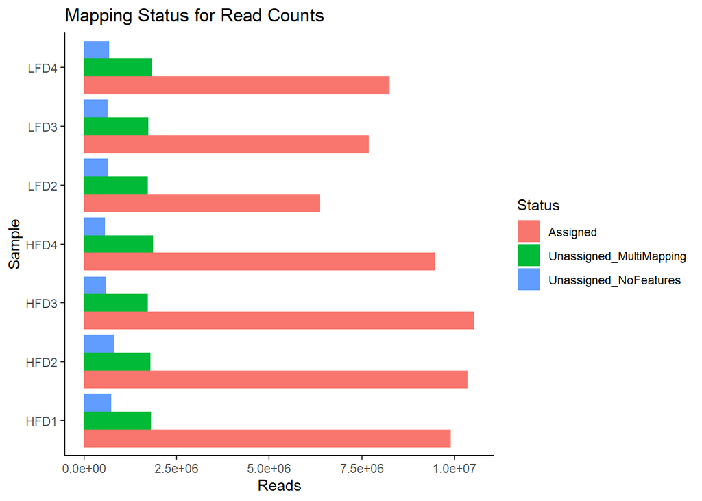

```r
plot.rc.summary <- ggplot(rc.summary, aes(x = Sample, y = Reads, fill = Status)) + geom_bar(stat = "identity", position = "dodge") +
  labs(x = "Sample", y = "Reads", fill = "Status") +
  theme_classic() + coord_flip() + ggtitle("Mapping Status for Read Counts")

plot.rc.summary
```

Next I examined the featureCounts data

```r
rc.data <- read.table("C:/Users/hamal/OneDrive/Documents/ANGSD/Project/Project_Files/project_featureCounts.txt", header = TRUE)

names(rc.data)[7:13] <- sapply(names(rc.data[7:13]), function(x) gsub(".*(LFD|HFD)([0-9]).*", "\\1\\2", x))
```

Converted the featureCounts data into a DESeq object

```r
#make Geneids into row names
row.names(rc.data) <- make.names(rc.data$Geneid)

#exclude columns without read counts
rc.data <- rc.data[ , -c(1:6)]

#create colData dataframe
sample_info <- data.frame(condition = gsub("[0-9]", "", names(rc.data)),
                          row.names = names(rc.data))

#create DESeq object
deseq.ds <- DESeqDataSetFromMatrix(countData = as.matrix(rc.data),
                                   colData = sample_info,
                                   design = ~ condition)
#remove genes with no reads
keep_genes <- rowSums(counts(deseq.ds)) > 0
deseq.ds <- deseq.ds[keep_genes, ]

#put samples in alphabetical order
deseq.ds <- deseq.ds[,sort(colnames(deseq.ds))]
```

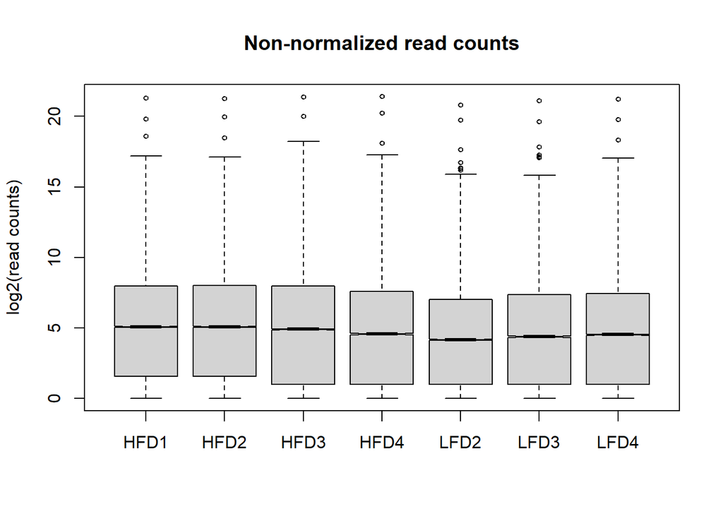

```r
#calculate size factors
deseq.ds <- estimateSizeFactors(deseq.ds)

#view effect of size factor normalization on counts
boxplot(log2(counts(deseq.ds) +1), notch=TRUE,
        main = "Non-normalized read counts",
        ylab = "log2(read counts)", cex = 0.6)
```

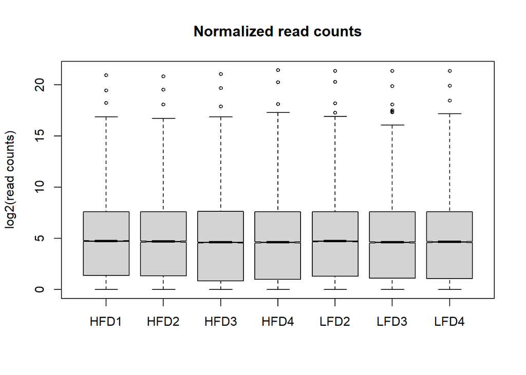

```r
boxplot(log2(counts(deseq.ds, normalized = TRUE) + 1), notch=TRUE,
        main = "Normalized read counts",
        ylab = "log2(read counts)", cex = 0.6)
```

As a sanity check, I plotted the normalized count of Ins2 and Gcg. Since all samples are beta cells, Ins2 should show much higher counts than Gcg across all samples. The plots show this is the case.

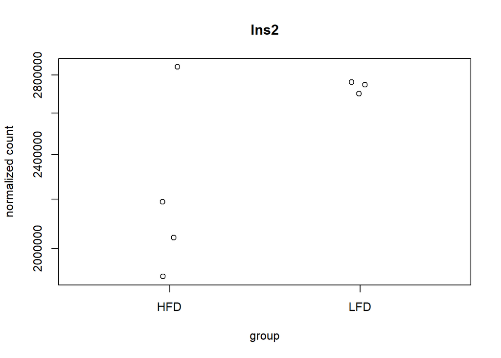

```r
plotCounts(deseq.ds, 'Ins2')
```

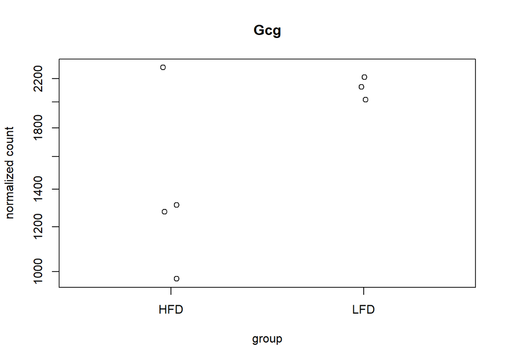

```r
plotCounts(deseq.ds, 'Gcg')
```

Next I examined sample clustering.

```r
#apply rlog normalization
dds.rlg <- rlog(deseq.ds, blind=FALSE)
```

The clustering heatmap shows that samples from each condition cluster together, confirming that the different conditions are associated with different transcriptional profiles.

It is interesting to observe that there appear to be pairs of similar samples within each condition, potentially indicating small batch effects. Similar pairs of HFD samples were observed from RSeQC gene body distribution plots.

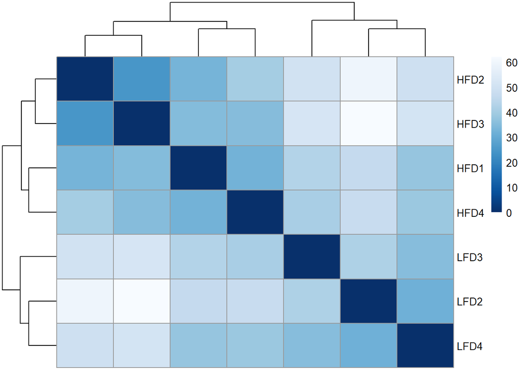

```r
#get sample-sample distances
sampleDists <- dist(t(assay(dds.rlg)))

#construct heatmap of sample-sample distances
sampleDistMatrix <- as.matrix(sampleDists)
colnames(sampleDistMatrix) <- NULL
colors <- colorRampPalette( rev(brewer.pal(9, "Blues")) )(255)
pheatmap(sampleDistMatrix,
         clustering_distance_rows=sampleDists,
         clustering_distance_cols=sampleDists,
         col=colors)
```

PCA also shows that the conditions form seperate clusters, with pairs within each condition.

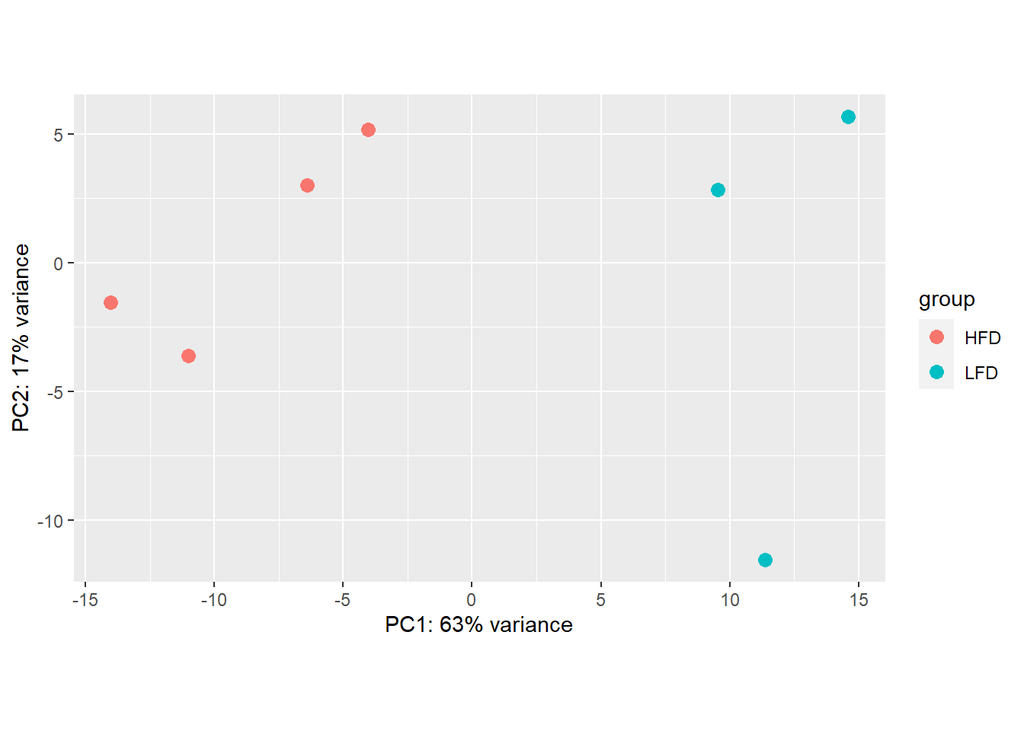

```r
plotPCA(dds.rlg, intgroup=c("condition"))
```